# AutoML: aman Yield Prediction

Zia Ahmed, Unversity at Buffalo

```r
setwd(gsub(pattern = '/scripts', replacement = '', x = getwd()))
```

# AutoML: Automatic Machine Learning

In recent years, the demand for machine learning experts has outpaced the supply, despite the surge of people entering the field. To address this gap, there have been big strides in the development of user-friendly machine learning software that can be used by non-experts. The first steps toward simplifying machine learning involved developing simple, unified interfaces to a variety of machine learning algorithms (e.g. H2O).

Although H2O has made it easy for non-experts to experiment with machine learning, there is still a fair bit of knowledge and background in data science that is required to produce high-performing machine learning models. Deep Neural Networks in particular are notoriously difficult for a non-expert to tune properly. In order for machine learning software to truly be accessible to non-experts, we have designed an easy-to-use interface which automates the process of training a large selection of candidate models. H2O’s AutoML can also be a helpful tool for the advanced user, by providing a simple wrapper function that performs a large number of modeling-related tasks that would typically require many lines of code, and by freeing up their time to focus on other aspects of the data science pipeline tasks such as data-preprocessing, feature engineering and model deployment.

H2O’s AutoML can be used for automating the machine learning workflow, which includes automatic training and tuning of many models within a user-specified time-limit. Stacked Ensembles – one based on all previously trained models, another one on the best model of each family – will be automatically trained on collections of individual models to produce highly predictive ensemble models which, in most cases, will be the top performing models in the AutoML Leaderboard.

H2O offers a number of model explainability methods that apply to AutoML objects (groups of models), as well as individual models (e.g. leader model). Explanations can be generated automatically with a single function call, providing a simple interface to exploring and explaining the AutoML models.

#### Set working directory

```r
#setwd("D:/Dropbox/CIMMYT_UB/NEW_ANALYSIS/ANALYSIS/AMAN")
setwd("/home/zia207/Dropbox/CIMMYT_UB/NEW_ANALYSIS/ANALYSIS/Yield/AMAN/AutoML_Aman_Yield/NewAnalysis")
```

#### Load Pcakages

```r
library(plyr)
library(tidyverse)
library(dplyr)
library(classInt)
library(data.table)
library(magrittr)
library(DT)
#library(kableExtra)
require(reshape2)
#library(pROC)
library(pdp)       # for partial dependence plots (and ICE curves)
library(vip)       # for variable importance plots
library(iml)       # for general IML-related functions
library(DALEX)     # for general IML-related functions
library(lime)      # for local interpretable model-agnostic explanations
library(breakDown)
library(iBreakDown)
#library(localICE)
#library(tidyquant) #for better ggplot theme
library(purrrlyr)
```

### Load data

```r
mf<-read.csv("aman_data_all.csv", header = T)
train.mf<-read.csv("train_data.csv", header = T)
test.mf<-read.csv("test_data.csv", header = T)
```

```r
names(mf)
```

```
##  [1] "Index"              "Crop"               "Seasons"
##  [4] "Crop_Types"         "Seasons_types"      "UNION_CODE"
##  [7] "x"                  "y"                  "LONG"
## [10] "LAT"                "DIVISION"           "DISTRICT"
## [13] "UPAZILA"            "UNION"              "Total_GWP"
## [16] "Emission_Intensity" "YIELD"              "GD"
## [19] "N_rate"             "P_rate"             "K_rate"
## [22] "pH"                 "SOC"                "N"
## [25] "P"                  "K"                  "S"
## [28] "Zn"                 "DEM"                "NDVI_193"
## [31] "NDVI_205"           "NDVI_225"           "NDVI_241"
## [34] "NDVI_257"           "NDVI_273"           "NDVI_289"
## [37] "NDVI_305"           "NDVI_321"           "NDVI_337"
## [40] "NDVI_353"           "t2m_193"            "t2m_209"
## [43] "t2m_225"            "t2m_241"            "t2m_257"
## [46] "t2m_273"            "t2m_289"            "t2m_305"
## [49] "t2m_321"            "t2m_337"            "t2m_353"
## [52] "tp_193"             "tp_209"             "tp_225"
## [55] "tp_241"             "tp_257"             "tp_273"
## [58] "tp_289"             "tp_305"             "tp_321"
## [61] "tp_337"             "tp_353"             "Soil_texture"
## [64] "Water_regime"       "Manure"             "LT_Class"
## [67] "DRC_Class"          "General_Soil_type"  "TZONE_Class"
## [70] "New_DRC"            "LT_ID"              "STYPE_ID"
## [73] "TZONE_ID"           "X"                  "DRC"
## [76] "DRC_CLASS_old"
```

### Create data frame-function

```r
FeatureData <- function(data) {
  features <- c(
                "GD",              # 1
                "N_rate",          # 2
                "P_rate",          # 3
                "K_rate",          # 4

                "pH",              # 5
                "SOC",             # 6
                "N",               # 7
                "P",               # 8
                "K",               # 9
                "S",               # 10
                "Zn",              # 11

                "DEM",             # 12

                "NDVI_193",      # 13
                "NDVI_205",      # 14
                "NDVI_225",      # 15
                "NDVI_241",      # 16
                "NDVI_257",      # 17
                "NDVI_273",      # 18
                "NDVI_289",      # 19
                "NDVI_305",      # 20
                "NDVI_321",      # 21
                "NDVI_337",      # 22
                "NDVI_353",      # 23

                "t2m_193",      # 24
                "t2m_209",      # 25
                "t2m_225",      # 26
                "t2m_241",      # 27
                "t2m_257",      # 28
                "t2m_273",      # 29
                "t2m_289",      # 30
                "t2m_305",      # 31
                "t2m_321",      # 32
                "t2m_337",      # 33
                "t2m_353",      # 34

                "tp_193",       # 35
                "tp_209",       # 36
                "tp_225",       # 37
                "tp_241",       # 38
                "tp_257",       # 39
                "tp_273",       # 40
                "tp_289",       # 41
                "tp_305",       # 42
                "tp_321",       # 43
                "tp_337",       # 44
                 "tp_353",      # 45

                "Crop_Types",        # 46
                "LT_Class",          # 47
                "General_Soil_type", # 48
                "DRC_Class",         # 49
                "TZONE_Class",       # 50
                "Soil_texture",      # 51
                "Water_regime",      # 52
                "Manure",            # 53

                "YIELD")            # 54
                fea <- data[,features]
                fea[, 1:45] = scale(fea[, 1:45])            # scale predictors
                fea[,46:53]= dmap(fea[,46:53], as.factor)   # convert to factors
                return(fea)
                 }
```

```r
df<-FeatureData(mf)
train.df<-FeatureData(train.mf)
test.df<-FeatureData(test.mf)
```

```r
write.csv(train.df, "train_data_scaled.csv", row.names = T)
write.csv(test.df, "test_data_scaled.csv", row.names = T)
```

### Connect to H2o server

```r
library(h2o)
h2o.init(nthreads = -1,max_mem_size ="48g",enable_assertions = FALSE)
```

```r
h2o.no_progress() # disable progress bar for RMarkdown
h2o.removeAll()   # Optional: remove anything from previous session
```

### Create h2o dataframe

```r
h_df<-  as.h2o(df)
h_train<-  as.h2o(train.df)
h_test<- as.h2o(test.df)
```

### Define response and predictors

```r
y <- "YIELD"
x <- setdiff(names(h_train), y)
```

### Create data frame for Explianers

### All Data

```r
x_all <- as.data.frame(h_df) %>% dplyr::select(-YIELD)
y_all<- as.data.frame(h_df) %>% pull(YIELD)
```

### Training

```r
x_train <- as.data.frame(h_train) %>% dplyr::select(-YIELD)
y_train <- as.data.frame(h_train) %>% pull(YIELD)
```

### Test

```r
x_test <- as.data.frame(h_test) %>% dplyr::select(-YIELD)
y_test <- as.data.frame(h_test) %>% pull(YIELD)
```

# Auto ML

```r
train.aml <- h2o.automl(
                  x= x,
                  y = y,
                  training_frame = h_train,
                  nfolds=10,
                  keep_cross_validation_predictions = TRUE,
                  stopping_metric = "RMSE",
                  stopping_tolerance = 0.001,
                  stopping_rounds = 3,
                  max_runtime_secs_per_model = 0,
                  seed = 42,
                  #max_models = 20,
                  project_name = "AutoML_trainings")
```

## Leaderboard

Next, we will view the AutoML Leaderboard. A default performance metric for each machine learning task (binary classification, multiclass classification, regression) is specified internally and the leaderboard will be sorted by that metric. In the case of regression, the default ranking metric is mean residual deviance. In the future, the user will be able to specify any of the H2O metrics so that different metrics can be used to generate rankings on the leaderboard.

```r
lb <- h2o.get_leaderboard(object = train.aml, extra_columns = "ALL")
datatable(as.data.frame(lb),
          rownames = FALSE, options = list(pageLength = 10, scrollX = TRUE, round)) %>%
  formatRound(columns = -1, digits = 4)
write.csv(as.data.frame(lb), "Model_Stat_AutoML.csv", row.names = F)
```

### The best Model

```r
best_ML<- h2o.get_best_model(train.aml, criterion = "RMSE" )
best_ML
```

```
## Model Details:
## ==============
##
## H2ORegressionModel: stackedensemble
## Model ID:  StackedEnsemble_AllModels_4_AutoML_3_20211127_174647
## Number of Base Models: 175
##
## Base Models (count by algorithm type):
##
## deeplearning          drf          gbm          glm      xgboost
##           10            2          130            1           32
##
## Metalearner:
##
## Metalearner algorithm: glm
## Metalearner cross-validation fold assignment:
##   Fold assignment scheme: AUTO
##   Number of folds: 10
##   Fold column: NULL
## Metalearner hyperparameters:
##
##
## H2ORegressionMetrics: stackedensemble
## ** Reported on training data. **
##
## MSE:  195776.2
## RMSE:  442.466
## MAE:  309.8508
## RMSLE:  0.1922019
## Mean Residual Deviance :  195776.2
##
##
##
## H2ORegressionMetrics: stackedensemble
## ** Reported on cross-validation data. **
## ** 10-fold cross-validation on training data (Metrics computed for combined holdout predictions) **
##
## MSE:  861557.8
## RMSE:  928.2014
## MAE:  648.4419
## RMSLE:  0.3421083
## Mean Residual Deviance :  861557.8
```

### Save Model

```r
model_path <- h2o.saveModel(object = best_ML, path = getwd(), force = TRUE)
print(model_path)
```

```
## [1] "/home/zia207/Dropbox/CIMMYT_UB/NEW_ANALYSIS/ANALYSIS/Yield/AMAN/AutoML_Aman_Yield/NewAnalysis/StackedEnsemble_AllModels_4_AutoML_3_20211127_174647"
```

### The best Stack Ensemble of all models

```r
model_ids<-as.data.frame(lb)$model_id
stack_all<-h2o.getModel(grep("StackedEnsemble_AllModels", model_ids, value=TRUE)[1])
stack_all_meta<-stack_all@model$metalearner_model
stack_all_meta
```

```
## Model Details:
## ==============
##
## H2ORegressionModel: glm
## Model ID:  metalearner_AUTO_StackedEnsemble_AllModels_4_AutoML_3_20211127_174647
## GLM Model: summary
##     family     link                              regularization
## 1 gaussian identity Elastic Net (alpha = 0.5, lambda = 2687.3 )
##   number_of_predictors_total number_of_active_predictors number_of_iterations
## 1                        175                           9                    1
##                                                           training_frame
## 1 levelone_training_StackedEnsemble_AllModels_4_AutoML_3_20211127_174647
##
## Coefficients: glm coefficients
##                                          names coefficients
## 1                                    Intercept   -45.176743
## 2               DRF_1_AutoML_3_20211127_174647     0.133568
## 3               XRT_1_AutoML_3_20211127_174647     0.174048
## 4 GBM_grid_1_AutoML_3_20211127_174647_model_48     0.240174
## 5 GBM_grid_1_AutoML_3_20211127_174647_model_34     0.129302
##   standardized_coefficients
## 1               3554.519887
## 2                151.799162
## 3                195.349422
## 4                279.547418
## 5                149.936864
##
## ---
##                                                    names coefficients
## 171 DeepLearning_grid_2_AutoML_3_20211127_174647_model_2     0.000000
## 172 DeepLearning_grid_1_AutoML_3_20211127_174647_model_4     0.000000
## 173 DeepLearning_grid_3_AutoML_3_20211127_174647_model_2     0.014092
## 174 DeepLearning_grid_1_AutoML_3_20211127_174647_model_5     0.000000
## 175        GBM_grid_1_AutoML_3_20211127_174647_model_125     0.000000
## 176                       GLM_1_AutoML_3_20211127_174647     0.000000
##     standardized_coefficients
## 171                  0.000000
## 172                  0.000000
## 173                 11.110568
## 174                  0.000000
```

[output cut: 59 more lines]

```
## mse                        957243.100000     928273.700000     897668.400000
## null_deviance          1190958340.000000 1253660800.000000 1085342590.000000
## r2                              0.590085          0.572179          0.587080
## residual_deviance       487236768.000000  534685664.000000  447936512.000000
## rmse                          978.388060        963.469600        947.453600
## rmsle                           0.389771          0.306740          0.349231
##                               cv_8_valid        cv_9_valid      cv_10_valid
## mae                           646.541700        645.243800       614.533570
## mean_residual_deviance     857651.250000     813980.560000    703053.500000
## mse                        857651.250000     813980.560000    703053.500000
## null_deviance          1130323580.000000 1120048900.000000 914859520.000000
## r2                              0.614473          0.607339         0.616160
## residual_deviance       434829184.000000  436293568.000000 348011488.000000
## rmse                          926.094600        902.208700       838.482850
## rmsle                           0.339688          0.362292         0.282358
```

### The best Stack Ensemble best of family

```r
stack_best<-h2o.getModel(grep("StackedEnsemble_BestOfFamily", model_ids, value=TRUE)[1])
stack_best_meta<-stack_best@model$metalearner_model
stack_best_meta
```

```
## Model Details:
## ==============
##
## H2ORegressionModel: glm
## Model ID:  metalearner_AUTO_StackedEnsemble_BestOfFamily_4_AutoML_3_20211127_174647
## GLM Model: summary
##     family     link                              regularization
## 1 gaussian identity Elastic Net (alpha = 0.5, lambda = 2590.8 )
##   number_of_predictors_total number_of_active_predictors number_of_iterations
## 1                          6                           5                    1
##                                                              training_frame
## 1 levelone_training_StackedEnsemble_BestOfFamily_4_AutoML_3_20211127_174647
##
## Coefficients: glm coefficients
##                                                  names coefficients
## 1                                            Intercept     2.344035
## 2                       DRF_1_AutoML_3_20211127_174647     0.256676
## 3                       XRT_1_AutoML_3_20211127_174647     0.210382
## 4         GBM_grid_1_AutoML_3_20211127_174647_model_48     0.306510
## 5     XGBoost_grid_1_AutoML_3_20211127_174647_model_14     0.122477
## 6 DeepLearning_grid_1_AutoML_3_20211127_174647_model_2     0.102585
## 7                       GLM_1_AutoML_3_20211127_174647     0.000000
##   standardized_coefficients
## 1               3554.519887
## 2                291.710178
## 3                236.130079
## 4                356.757806
## 5                144.386657
## 6                111.242263
## 7                  0.000000
##
## H2ORegressionMetrics: glm
## ** Reported on training data. **
##
## MSE:  864462.8
## RMSE:  929.7649
## MAE:  651.9573
## RMSLE:  0.3427411
## Mean Residual Deviance :  864462.8
## R^2 :  0.5910698
```

[output cut: 47 more lines]

```
## mse                        969796.060000     785075.250000    752379.700000
## null_deviance          1110312190.000000 1147749500.000000 996948030.000000
## r2                              0.554725          0.605510         0.622539
## residual_deviance       492656384.000000  452203328.000000 375437472.000000
## rmse                          984.782200        886.044740       867.398250
## rmsle                           0.319124          0.320687         0.287589
##                               cv_8_valid        cv_9_valid       cv_10_valid
## mae                           598.456500        646.545840        623.602360
## mean_residual_deviance     720916.100000     834346.750000     841973.440000
## mse                        720916.100000     834346.750000     841973.440000
## null_deviance          1009816700.000000 1128355710.000000 1032052540.000000
## r2                              0.638557          0.600639          0.596164
## residual_deviance       364783552.000000  448044192.000000  416776864.000000
## rmse                          849.067800        913.425840        917.591100
## rmsle                           0.325690          0.373253          0.338637
```

### The best Stack

```r
best_stack <- h2o.get_best_model(train.aml, algorithm = "stackedensemble", criterion = "RMSE" )
best_stack
```

```
## Model Details:
## ==============
##
## H2ORegressionModel: stackedensemble
## Model ID:  StackedEnsemble_AllModels_4_AutoML_3_20211127_174647
## Number of Base Models: 175
##
## Base Models (count by algorithm type):
##
## deeplearning          drf          gbm          glm      xgboost
##           10            2          130            1           32
##
## Metalearner:
##
## Metalearner algorithm: glm
## Metalearner cross-validation fold assignment:
##   Fold assignment scheme: AUTO
##   Number of folds: 10
##   Fold column: NULL
## Metalearner hyperparameters:
##
##
## H2ORegressionMetrics: stackedensemble
## ** Reported on training data. **
##
## MSE:  195776.2
## RMSE:  442.466
## MAE:  309.8508
## RMSLE:  0.1922019
## Mean Residual Deviance :  195776.2
##
##
##
## H2ORegressionMetrics: stackedensemble
## ** Reported on cross-validation data. **
## ** 10-fold cross-validation on training data (Metrics computed for combined holdout predictions) **
##
## MSE:  861557.8
## RMSE:  928.2014
## MAE:  648.4419
## RMSLE:  0.3421083
## Mean Residual Deviance :  861557.8
```

### The best GLM

```r
best_GLM <- h2o.get_best_model(train.aml, algorithm = "glm", criterion = "RMSE" )
best_GLM
```

```
## Model Details:
## ==============
##
## H2ORegressionModel: glm
## Model ID:  GLM_1_AutoML_3_20211127_174647
## GLM Model: summary
##     family     link             regularization
## 1 gaussian identity Ridge ( lambda = 12642.0 )
##                                                                    lambda_search
## 1 nlambda = 30, lambda.max = 52782.0, lambda.min = 12642.0, lambda.1se = 52782.0
##   number_of_predictors_total number_of_active_predictors number_of_iterations
## 1                        100                         100                    4
##                                          training_frame
## 1 AutoML_3_20211127_174647_training_train.df_sid_be95_3
##
## Coefficients: glm coefficients
##                                   names coefficients standardized_coefficients
## 1                             Intercept  3554.511699               3554.511699
## 2    General_Soil_type.Acid Basin Clays     0.000575                  0.000575
## 3 General_Soil_type.Acid Sulphate Soils    -0.001142                 -0.001142
## 4  General_Soil_type.Black Terrai Soils     0.000127                  0.000127
## 5    General_Soil_type.Brown Hill Soils     0.000406                  0.000406
##
## ---
##      names coefficients standardized_coefficients
## 96  tp_273    -0.002445                 -0.002445
## 97  tp_289    -0.007025                 -0.007025
## 98  tp_305     0.017383                  0.017383
## 99  tp_321    -0.004486                 -0.004486
## 100 tp_337     0.011344                  0.011344
## 101 tp_353     0.006567                  0.006567
##
## H2ORegressionMetrics: glm
## ** Reported on training data. **
##
## MSE:  2113738
## RMSE:  1453.87
## MAE:  1190.663
## RMSLE:  0.526735
## Mean Residual Deviance :  2113738
```

[output cut: 48 more lines]

```
## mse                       2172983.800000    2041822.800000    2047639.200000
## null_deviance          1154015620.000000 1082340350.000000 1085402110.000000
## r2                             -0.000119          0.000150         -0.000537
## residual_deviance      1153854460.000000 1082166140.000000 1085248770.000000
## rmse                         1474.104400       1428.923700       1430.957500
## rmsle                           0.526129          0.527428          0.523260
##                               cv_8_valid        cv_9_valid       cv_10_valid
## mae                          1131.500900       1203.471300       1165.965300
## mean_residual_deviance    1922611.000000    2119499.000000    2023172.000000
## mse                       1922611.000000    2119499.000000    2023172.000000
## null_deviance          1019159490.000000 1123511040.000000 1072435520.000000
## r2                             -0.000469         -0.000868         -0.000235
## residual_deviance      1018983810.000000 1123334400.000000 1072281150.000000
## rmse                         1386.582500       1455.849900       1422.382600
## rmsle                           0.479711          0.521571          0.545487
```

### The best DRF

```r
best_DRF <- h2o.get_best_model(train.aml, algorithm = "DRF", criterion = "RMSE" )
best_DRF
```

```
## Model Details:
## ==============
##
## H2ORegressionModel: drf
## Model ID:  DRF_1_AutoML_3_20211127_174647
## Model Summary:
##   number_of_trees number_of_internal_trees model_size_in_bytes min_depth
## 1              50                       50             1274730        20
##   max_depth mean_depth min_leaves max_leaves mean_leaves
## 1        20   20.00000       1832       2209  2024.12000
##
##
## H2ORegressionMetrics: drf
## ** Reported on training data. **
## ** Metrics reported on Out-Of-Bag training samples **
##
## MSE:  899865.2
## RMSE:  948.6122
## MAE:  661.3414
## RMSLE:  0.3437964
## Mean Residual Deviance :  899865.2
##
##
##
## H2ORegressionMetrics: drf
## ** Reported on cross-validation data. **
## ** 10-fold cross-validation on training data (Metrics computed for combined holdout predictions) **
##
## MSE:  889901.3
## RMSE:  943.3458
## MAE:  657.0159
## RMSLE:  0.3443406
## Mean Residual Deviance :  889901.3
##
##
## Cross-Validation Metrics Summary:
##                                 mean           sd    cv_1_valid    cv_2_valid
## mae                       657.006350    27.728848    653.558960    622.011500
## mean_residual_deviance 889877.500000 88792.410000 855246.060000 784147.100000
## mse                    889877.500000 88792.410000 855246.060000 784147.100000
## r2                          0.578559     0.035080      0.591219      0.650320
## residual_deviance      889877.500000 88792.410000 855246.060000 784147.100000
## rmse                      942.313350    46.224716    924.795170    885.520800
## rmsle                       0.343595     0.023837      0.360964      0.299613
##                            cv_3_valid    cv_4_valid    cv_5_valid    cv_6_valid
## mae                        720.508200    676.183500    663.122200    652.754900
## mean_residual_deviance 1086772.800000 951721.560000 897643.400000 853231.700000
## mse                    1086772.800000 951721.560000 897643.400000 853231.700000
## r2                           0.521203      0.565463      0.586858      0.582185
## residual_deviance      1086772.800000 951721.560000 897643.400000 853231.700000
## rmse                      1042.483900    975.562200    947.440400    923.705400
## rmsle                        0.374450      0.353326      0.338291      0.357136
##                           cv_7_valid    cv_8_valid    cv_9_valid   cv_10_valid
## mae                       640.698670    645.175540    666.198300    629.852200
## mean_residual_deviance 921242.000000 839861.600000 919982.940000 788925.700000
## mse                    921242.000000 839861.600000 919982.940000 788925.700000
## r2                          0.549854      0.562961      0.565566      0.609963
## residual_deviance      921242.000000 839861.600000 919982.940000 788925.700000
## rmse                      959.813540    916.439640    959.157400    888.214900
## rmsle                       0.336608      0.316501      0.329961      0.369105
```

### The best XRT

```r
best_XRT<-h2o.getModel(grep("XRT", model_ids, value=TRUE)[1])
best_XRT
```

```
## Model Details:
## ==============
##
## H2ORegressionModel: drf
## Model ID:  XRT_1_AutoML_3_20211127_174647
## Model Summary:
##   number_of_trees number_of_internal_trees model_size_in_bytes min_depth
## 1              49                       49             1197790        20
##   max_depth mean_depth min_leaves max_leaves mean_leaves
## 1        20   20.00000       1707       2127  1939.73470
##
##
## H2ORegressionMetrics: drf
## ** Reported on training data. **
## ** Metrics reported on Out-Of-Bag training samples **
##
## MSE:  913985.1
## RMSE:  956.0257
## MAE:  670.7723
## RMSLE:  0.3492919
## Mean Residual Deviance :  913985.1
##
##
##
## H2ORegressionMetrics: drf
## ** Reported on cross-validation data. **
## ** 10-fold cross-validation on training data (Metrics computed for combined holdout predictions) **
##
## MSE:  893266.7
## RMSE:  945.1279
## MAE:  662.1869
## RMSLE:  0.3471077
## Mean Residual Deviance :  893266.7
##
##
## Cross-Validation Metrics Summary:
##                                 mean           sd    cv_1_valid    cv_2_valid
## mae                       662.177600    29.547798    660.185800    626.977500
## mean_residual_deviance 893245.700000 89738.410000 856418.400000 778343.500000
## mse                    893245.700000 89738.410000 856418.400000 778343.500000
## r2                          0.576944     0.035586      0.590658      0.652908
## residual_deviance      893245.700000 89738.410000 856418.400000 778343.500000
## rmse                      944.084100    46.557770    925.428800    882.237800
## rmsle                       0.346364     0.023953      0.359813      0.300949
##                            cv_3_valid    cv_4_valid    cv_5_valid    cv_6_valid
## mae                        732.378900    684.207000    656.516050    666.257140
## mean_residual_deviance 1095579.100000 957813.060000 889567.060000 884115.100000
## mse                    1095579.100000 957813.060000 889567.060000 884115.100000
## r2                           0.517323      0.562682      0.590576      0.567062
## residual_deviance      1095579.100000 957813.060000 889567.060000 884115.100000
## rmse                      1046.699200    978.679260    943.168640    940.274000
## rmsle                        0.370753      0.357061      0.339367      0.367623
##                           cv_7_valid    cv_8_valid    cv_9_valid   cv_10_valid
## mae                       643.461360    645.808170    666.509030    639.475040
## mean_residual_deviance 916588.100000 829940.750000 917786.900000 806304.800000
## mse                    916588.100000 829940.750000 917786.900000 806304.800000
## r2                          0.552128      0.568124      0.566604      0.601371
## residual_deviance      916588.100000 829940.750000 917786.900000 806304.800000
## rmse                      957.386100    911.010860    958.011960    897.944760
## rmsle                       0.343660      0.316758      0.334920      0.372733
```

### The best GBM

```r
best_GBM <- h2o.get_best_model(train.aml, algorithm = "GBM", criterion = "RMSE" )
best_GBM
```

```
## Model Details:
## ==============
##
## H2ORegressionModel: gbm
## Model ID:  GBM_grid_1_AutoML_3_20211127_174647_model_48
## Model Summary:
##   number_of_trees number_of_internal_trees model_size_in_bytes min_depth
## 1              64                       64              312158        15
##   max_depth mean_depth min_leaves max_leaves mean_leaves
## 1        15   15.00000        120        634   383.25000
##
##
## H2ORegressionMetrics: gbm
## ** Reported on training data. **
##
## MSE:  215147.6
## RMSE:  463.8401
## MAE:  311.7589
## RMSLE:  0.1963449
## Mean Residual Deviance :  215147.6
##
##
##
## H2ORegressionMetrics: gbm
## ** Reported on cross-validation data. **
## ** 10-fold cross-validation on training data (Metrics computed for combined holdout predictions) **
##
## MSE:  895910.5
## RMSE:  946.5255
## MAE:  661.5709
## RMSLE:  0.3466162
## Mean Residual Deviance :  895910.5
##
##
## Cross-Validation Metrics Summary:
##                                 mean           sd    cv_1_valid    cv_2_valid
## mae                       661.017000    32.968376    661.697100    630.675540
## mean_residual_deviance 901084.250000 94943.890000 869036.600000 804952.250000
## mse                    901084.250000 94943.890000 869036.600000 804952.250000
## r2                          0.573650     0.033664      0.584627      0.641042
## residual_deviance      901084.250000 94943.890000 869036.600000 804952.250000
## rmse                      948.092000    49.506992    932.221400    897.191350
## rmsle                       0.346122     0.025530      0.362130      0.304791
##                            cv_3_valid    cv_4_valid    cv_5_valid    cv_6_valid
## mae                        715.061400    695.681900    676.925900    670.984740
## mean_residual_deviance 1090058.200000 980325.100000 935049.750000 881998.400000
## mse                    1090058.200000 980325.100000 935049.750000 881998.400000
## r2                           0.519755      0.552404      0.569642      0.568099
## residual_deviance      1090058.200000 980325.100000 935049.750000 881998.400000
## rmse                      1044.058600    990.113700    966.979740    939.147700
## rmsle                        0.377361      0.360050      0.343971      0.361729
##                           cv_7_valid    cv_8_valid    cv_9_valid   cv_10_valid
## mae                       629.147800    611.152500    680.386660    638.456850
## mean_residual_deviance 900702.700000 778399.000000 961950.400000 808369.940000
## mse                    900702.700000 778399.000000 961950.400000 808369.940000
## r2                          0.559890      0.594945      0.545749      0.600350
## residual_deviance      900702.700000 778399.000000 961950.400000 808369.940000
## rmse                      949.053600    882.269200    980.790700    899.094000
## rmsle                       0.328935      0.310217      0.337269      0.374769
```

### The best XGBoost

```r
best_XGBoost <- h2o.get_best_model(train.aml, algorithm = "xgboost", criterion = "RMSE" )
best_XGBoost
```

```
## Model Details:
## ==============
##
## H2ORegressionModel: xgboost
## Model ID:  XGBoost_grid_1_AutoML_3_20211127_174647_model_14
## Model Summary:
##   number_of_trees
## 1              73
##
##
## H2ORegressionMetrics: xgboost
## ** Reported on training data. **
##
## MSE:  204778.8
## RMSE:  452.5249
## MAE:  298.0165
## RMSLE:  0.1943731
## Mean Residual Deviance :  204778.8
##
##
##
## H2ORegressionMetrics: xgboost
## ** Reported on cross-validation data. **
## ** 10-fold cross-validation on training data (Metrics computed for combined holdout predictions) **
##
## MSE:  912693.6
## RMSE:  955.35
## MAE:  666.7589
## RMSLE:  0.3495616
## Mean Residual Deviance :  912693.6
##
##
## Cross-Validation Metrics Summary:
##                                 mean            sd    cv_1_valid    cv_2_valid
## mae                       666.738400     37.295612    673.429100    643.849730
## mean_residual_deviance 912640.200000 101222.470000 922771.060000 841872.560000
## mse                    912640.200000 101222.470000 922771.060000 841872.560000
## r2                          0.568342      0.035000      0.558944      0.624578
## residual_deviance      912640.200000 101222.470000 922771.060000 841872.560000
## rmse                      954.039250     52.167980    960.609740    917.536130
```

[output cut: 10 more lines]

```
## mae                       675.153930    625.587650    641.923340    670.954650
## mean_residual_deviance 874799.700000 886998.100000 814710.400000 924231.000000
## mse                    874799.700000 886998.100000 814710.400000 924231.000000
## r2                          0.571624      0.566586      0.576049      0.563561
## residual_deviance      874799.700000 886998.100000 814710.400000 924231.000000
## rmse                      935.307250    941.805800    902.613100    961.369300
## rmsle                       0.365697      0.335389      0.313937      0.327923
##                          cv_10_valid
## mae                       611.504700
## mean_residual_deviance 778920.100000
## mse                    778920.100000
## r2                          0.614910
## residual_deviance      778920.100000
## rmse                      882.564500
## rmsle                       0.371462
```

### The best DNN

```r
best_DNN <- h2o.get_best_model(train.aml, algorithm = "DeepLearning", criterion = "RMSE" )
best_DNN
```

```
## Model Details:
## ==============
##
## H2ORegressionModel: deeplearning
## Model ID:  DeepLearning_grid_1_AutoML_3_20211127_174647_model_2
## Status of Neuron Layers: predicting YIELD, regression, gaussian distribution, Quadratic loss, 11,001 weights/biases, 140.4 KB, 2,811,650 training samples, mini-batch size 1
##   layer units             type dropout       l1       l2 mean_rate rate_rms
## 1     1   108            Input  0.00 %       NA       NA        NA       NA
## 2     2   100 RectifierDropout 20.00 % 0.000000 0.000000  0.079895 0.260319
## 3     3     1           Linear      NA 0.000000 0.000000  0.000196 0.000083
##   momentum mean_weight weight_rms mean_bias bias_rms
## 1       NA          NA         NA        NA       NA
## 2 0.000000   -0.014933   0.125051  0.258605 0.065853
## 3 0.000000    0.042863   0.377036 -0.177889 0.000000
##
##
## H2ORegressionMetrics: deeplearning
## ** Reported on training data. **
## ** Metrics reported on full training frame **
##
## MSE:  696911.9
## RMSE:  834.8125
## MAE:  612.8563
## RMSLE:  0.3149669
## Mean Residual Deviance :  696911.9
##
##
##
## H2ORegressionMetrics: deeplearning
## ** Reported on cross-validation data. **
## ** 10-fold cross-validation on training data (Metrics computed for combined holdout predictions) **
##
## MSE:  1028646
## RMSE:  1014.222
## MAE:  749.5132
## RMSLE:  NaN
## Mean Residual Deviance :  1028646
##
##
## Cross-Validation Metrics Summary:
```

[output cut: 17 more lines]

```
## mae                       714.264340     722.124500    772.589540
## mean_residual_deviance 937848.700000 1016984.940000 994480.200000
## mse                    937848.700000 1016984.940000 994480.200000
## r2                          0.540750       0.503071      0.482503
## residual_deviance      937848.700000 1016984.940000 994480.200000
## rmse                      968.425900    1008.456700    997.236270
## rmsle                       0.384503       0.373120      0.343408
##                            cv_9_valid   cv_10_valid
## mae                        742.356300    702.930400
## mean_residual_deviance 1030924.250000 930868.000000
## mse                    1030924.250000 930868.000000
## r2                           0.513178      0.539788
## residual_deviance      1030924.250000 930868.000000
## rmse                      1015.344360    964.815000
## rmsle                        0.352674      0.394118
```

## Cross-validation results

```r
# Stack Ensemble of all model
cv.stack_all<-stack_all_meta@model$cross_validation_metrics_summary
write.csv(cv.stack_all, "cv.stack_all.csv")

# Stack Ensemble the best of family
cv.stack_best<-stack_best_meta@model$cross_validation_metrics_summary
write.csv(cv.stack_best, "cv.stack_best.csv")

# GLM
cv.GLM<-best_GLM@model$cross_validation_metrics_summary
write.csv(cv.GLM, "cv_best_GML.csv")

# DRF
cv.DRF<-best_DRF@model$cross_validation_metrics_summary
write.csv(cv.DRF, "cv_best_DRF.csv")

# XRT
cv.XRT<-best_XRT@model$cross_validation_metrics_summary
write.csv(cv.XRT, "cv_best_XRT.csv")

# GBM
cv.GBM<-best_GBM@model$cross_validation_metrics_summary
write.csv(cv.GBM, "cv_best_GBM.csv")

# XGBoost
cv.XGBoost<-best_XGBoost@model$cross_validation_metrics_summary
write.csv(cv.XGBoost, "cv_best_XGBoost.csv")

# DNN
cv.DNN<-best_DNN@model$cross_validation_metrics_summary
write.csv(cv.DNN, "cv_best_DNN.csv")
```

## RMSE - CV

```r
## Create a data-frame
glm.RMSE<-cv.GLM[7,c(1:2)]
drf.RMSE<-cv.DRF[6,c(1:2)]
xrt.RMSE<-cv.XRT[6,c(1:2)]
gbm.RMSE<-cv.GBM[6,c(1:2)]
xgboost.RMSE<-cv.XGBoost[6,c(1:2)]
dnn.RMSE<-cv.DNN[6,c(1:2)]
stack_all.RMSE<-cv.stack_all[7,c(1:2)]
stack_best.RMSE<-cv.stack_best[7,c(1:2)]

cv.RMSE<-rbind(glm.RMSE, drf.RMSE, xrt.RMSE, gbm.RMSE,
                   xgboost.RMSE, dnn.RMSE, stack_all.RMSE, stack_best.RMSE )

rownames(cv.RMSE) <- c("GLM ", "DRF ", "XRT", "GBM", "XGBoost", "DNN",
                           "Stack-Ensemble (all models)", "Stack-Ensemble (the best of family)")
cv.RMSE <- tibble::rownames_to_column(cv.RMSE, "Models")
cv.RMSE <-arrange(cv.RMSE ,desc(mean))

## Plot
tiff( file="FIGURE_CV_RMSE_aman.tif",
      width=7,   height=5,
      units = "in",
      pointsize = 10,
      res=600, bg = "white",
      compression =  "lzw")

cv.RMSE.p<-ggplot(cv.RMSE, aes(y=mean, x=reorder(Models, +mean))) +
  ylab('') +
  xlab('')+
  geom_point(colour = "black", size = 2.5)+
  geom_errorbar(aes(ymin=mean-sd,
                    ymax=mean+sd),
                width=.2,
                linetype=1,
                color ="dark grey") +
   #scale_y_continuous(limits=c(0.6,1), breaks=seq(0.6, 1, 0.2)) +
   theme(axis.line = element_line(colour = "grey"),
        axis.text.y=element_text(size=12),
        axis.text.x = element_text(size=10),
        axis.title.x = element_text(size=12),
        axis.title.y = element_text(size=12))+
  coord_flip()
print(cv.RMSE.p)
dev.off()
```

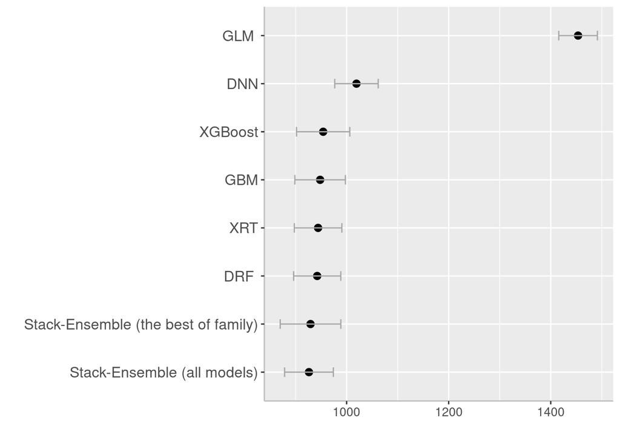

```r
print(cv.RMSE.p)
```

## MAE - CV

```r
## Create a data-frame
glm.MAE<-cv.GLM[1,c(1:2)]
drf.MAE<-cv.DRF[1,c(1:2)]
xrt.MAE<-cv.XRT[1,c(1:2)]
gbm.MAE<-cv.GBM[1,c(1:2)]
xgboost.MAE<-cv.XGBoost[1,c(1:2)]
dnn.MAE<-cv.DNN[1,c(1:2)]
stack_all.MAE<-cv.stack_all[1,c(1:2)]
stack_best.MAE<-cv.stack_best[1,c(1:2)]

cv.MAE<-rbind(glm.MAE, drf.MAE, xrt.MAE, gbm.MAE,
               xgboost.MAE, dnn.MAE, stack_all.MAE, stack_best.MAE )

rownames(cv.MAE) <- c("GLM ", "DRF ", "XRT", "GBM", "XGBoost", "DNN",
                       "Stack-Ensemble (all models)", "Stack-Ensemble (the best of family)")
cv.MAE <- tibble::rownames_to_column(cv.MAE, "Models")
cv.MAE <-arrange(cv.MAE ,desc(mean))

## Plot
tiff( file="FIGURE_CV_MAE_aman.tif",
      width=7,   height=5,
      units = "in",
      pointsize = 10,
      res=600, bg = "white",
      compression =  "lzw")

cv.MAE.p<-ggplot(cv.MAE, aes(y=mean, x=reorder(Models, +mean))) +
  ylab('') +
  xlab('')+
  geom_point(colour = "black", size = 2.5)+
  geom_errorbar(aes(ymin=mean-sd,
                    ymax=mean+sd),
                width=.2,
                linetype=1,
                color ="dark grey") +
  #scale_y_continuous(limits=c(0.6,1), breaks=seq(0.6, 1, 0.2)) +
  theme(axis.line = element_line(colour = "grey"),
        axis.text.y=element_text(size=12),
        axis.text.x = element_text(size=10),
        axis.title.x = element_text(size=12),
        axis.title.y = element_text(size=12))+
  coord_flip()
print(cv.MAE.p)
dev.off()
```

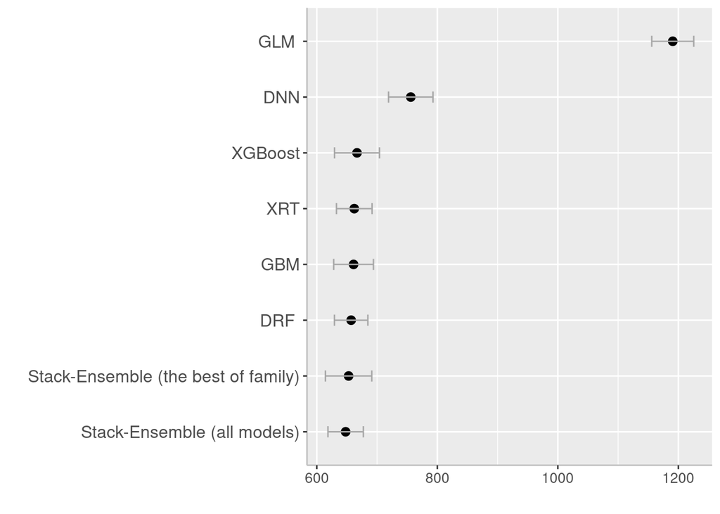

```r
print(cv.MAE.p)
```

## R2 - CV

```r
## Create a data-frame
glm.R2<-cv.GLM[5,c(1:2)]
drf.R2<-cv.DRF[4,c(1:2)]
xrt.R2<-cv.XRT[4,c(1:2)]
gbm.R2<-cv.GBM[4,c(1:2)]
xgboost.R2<-cv.XGBoost[4,c(1:2)]
dnn.R2<-cv.DNN[4,c(1:2)]
stack_all.R2<-cv.stack_all[5,c(1:2)]
stack_best.R2<-cv.stack_best[5,c(1:2)]

cv.R2<-rbind(glm.R2, drf.R2, xrt.R2, gbm.R2,
               xgboost.R2, dnn.R2, stack_all.R2, stack_best.R2 )

rownames(cv.R2) <- c("GLM ", "DRF ", "XRT", "GBM", "XGBoost", "DNN",
                       "Stack-Ensemble (all models)", "Stack-Ensemble (the best of family)")
cv.R2 <- tibble::rownames_to_column(cv.R2, "Models")
cv.R2 <-arrange(cv.R2 ,desc(mean))

## Plot
tiff( file="FIGURE_CV_R2_aman.tif",
      width=7,   height=5,
      units = "in",
      pointsize = 10,
      res=600, bg = "white",
      compression =  "lzw")

cv.R2.p<-ggplot(cv.R2, aes(y=mean, x=reorder(Models, +mean))) +
  ylab('') +
  xlab('')+
  geom_point(colour = "black", size = 2.5)+
  geom_errorbar(aes(ymin=mean-sd,
                    ymax=mean+sd),
                width=.2,
                linetype=1,
                color ="dark grey") +
  #scale_y_continuous(limits=c(0.6,1), breaks=seq(0.6, 1, 0.2)) +
  theme(axis.line = element_line(colour = "grey"),
        axis.text.y=element_text(size=12),
        axis.text.x = element_text(size=10),
        axis.title.x = element_text(size=12),
        axis.title.y = element_text(size=12))+
  coord_flip()
print(cv.R2.p)
dev.off()
```

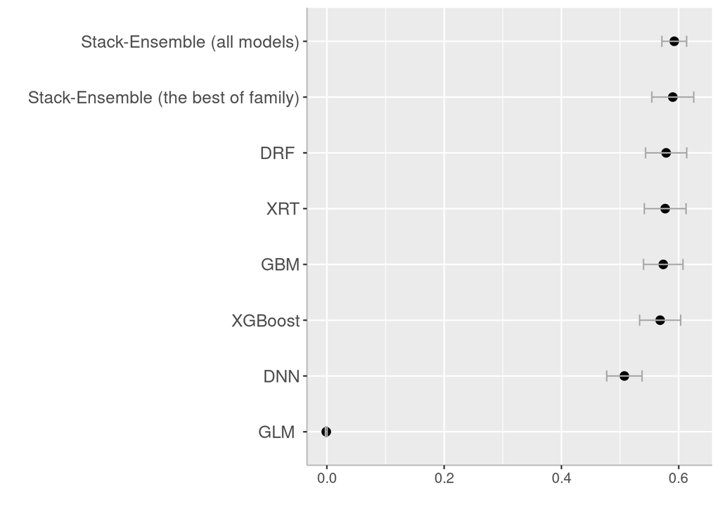

```r
print(cv.R2.p)
```

## Model Performance

### The best ML

```r
per.best.train<-h2o.performance(best_ML, h_train)
per.best.test<-h2o.performance(best_ML, h_test)
per.best.cv<-h2o.performance(best_stack, xval = TRUE)
#per.stack_best.train
per.best.test
```

```
## H2ORegressionMetrics: stackedensemble
##
## MSE:  900046.6
## RMSE:  948.7078
## MAE:  668.7095
## RMSLE:  0.3353876
## Mean Residual Deviance :  900046.6
```

```r
#per.stack_best.cv
```

### The best Stack-Ensemble

```r
per.stack_best.train<-h2o.performance(best_stack, h_train)
per.stack_best.test<-h2o.performance(best_stack, h_test)
per.stack_best.cv<-h2o.performance(best_stack, xval = TRUE)
#per.stack_best.train
per.stack_best.test
```

```
## H2ORegressionMetrics: stackedensemble
##
## MSE:  900046.6
## RMSE:  948.7078
## MAE:  668.7095
## RMSLE:  0.3353876
## Mean Residual Deviance :  900046.6
```

```r
#per.stack_best.cv
```

### The best GLM

```r
# ### Training
per.best_GLM.train<-h2o.performance(best_GLM, h_train)
per.best_GLM.test<-h2o.performance(best_GLM, h_test)
per.best_GLM.cv<-h2o.performance(best_GLM, xval = TRUE)
#per.best_GLM.train
per.best_GLM.test
```

```
## H2ORegressionMetrics: glm
##
## MSE:  2055569
## RMSE:  1433.725
## MAE:  1183.092
## RMSLE:  0.5008621
## Mean Residual Deviance :  2055569
## R^2 :  5.05611e-05
## Null Deviance :2791774209
## Null D.o.F. :1357
## Residual Deviance :2791462370
## Residual D.o.F. :1257
## AIC :23797.81
```

```r
#per.best_GLM.cv
```

### The best DRF

```r
# ### Training
per.best_DRF.train<-h2o.performance(best_DRF, h_train)
per.best_DRF.test<-h2o.performance(best_DRF, h_test)
per.best_DRF.cv<-h2o.performance(best_DRF, xval = TRUE)
#per.best_DRF.train
per.best_DRF.test
```

```
## H2ORegressionMetrics: drf
##
## MSE:  919789.8
## RMSE:  959.0567
## MAE:  672.6885
## RMSLE:  0.3381079
## Mean Residual Deviance :  919789.8
```

```r
#per.best_DRF.cv
```

### The best XRT

```r
# ### Training
per.best_XRT.train<-h2o.performance(best_XRT, h_train)
per.best_XRT.test<-h2o.performance(best_XRT, h_test)
per.best_XRT.cv<-h2o.performance(best_XRT, xval = TRUE)
#per.best_XRT.train
per.best_XRT.test
```

```
## H2ORegressionMetrics: drf
##
## MSE:  933837.6
## RMSE:  966.3527
## MAE:  685.1809
## RMSLE:  0.3384506
## Mean Residual Deviance :  933837.6
```

```r
#per.best_XRT.cv
```

### The best GBM

```r
# ### Training
per.best_GBM.train<-h2o.performance(best_GBM, h_train)
per.best_GBM.test<-h2o.performance(best_GBM, h_test)
per.best_GBM.cv<-h2o.performance(best_GBM, xval = TRUE)
#per.best_GBM.train
per.best_GBM.test
```

```
## H2ORegressionMetrics: gbm
##
## MSE:  941658.7
## RMSE:  970.391
## MAE:  685.5486
## RMSLE:  0.3415173
## Mean Residual Deviance :  941658.7
```

```r
#per.best_GBM.cv
```

### The best XGBoost

```r
# ### Training
per.best_XGBoost.train<-h2o.performance(best_XGBoost, h_train)
per.best_XGBoost.test<-h2o.performance(best_XGBoost, h_test)
per.best_XGBoost.cv<-h2o.performance(best_XGBoost, xval = TRUE)
#per.best_XGBoost.train
per.best_XGBoost.test
```

```
## H2ORegressionMetrics: xgboost
##
## MSE:  996659.3
## RMSE:  998.3283
## MAE:  726.2362
## RMSLE:  0.3490832
## Mean Residual Deviance :  996659.3
```

```r
#per.best_XGBoost.cv
```

### The best DNN

```r
# ### Training
per.best_DNN.train<-h2o.performance(best_DNN, h_train)
per.best_DNN.test<-h2o.performance(best_DNN, h_test)
per.best_DNN.cv<-h2o.performance(best_DNN, xval = TRUE)
#per.best_DNN.train
per.best_DNN.test
```

```
## H2ORegressionMetrics: deeplearning
##
## MSE:  1018426
## RMSE:  1009.171
## MAE:  743.5035
## RMSLE:  0.3586464
## Mean Residual Deviance :  1018426
```

```r
#per.best_DNN.cv
```

## Model Comparison - Training/CV/Test

## RMSE

```r
d_rmse <- data.frame(Models = c("GLM ",
                                   "DRF ",
                                   "XRT",
                                   "GBM",
                                   "XGBoost",
                                   "DNN",
                                   "Stack-Ensemble",
                                   "Best-ML"
),
stringsAsFactors = FALSE)

d_rmse$Training <- NA
d_rmse$CV <- NA
d_rmse$Test <- NA

## Training
d_rmse[1, ]$Training<-h2o.rmse(h2o.performance(best_GLM, newdata = h_train))
d_rmse[2, ]$Training<-h2o.rmse(h2o.performance(best_DRF, newdata = h_train))
d_rmse[3, ]$Training<-h2o.rmse(h2o.performance(best_XRT, newdata = h_train))
d_rmse[4, ]$Training<-h2o.rmse(h2o.performance(best_GBM, newdata = h_train))
d_rmse[5, ]$Training<-h2o.rmse(h2o.performance(best_XGBoost, newdata = h_train))
d_rmse[6, ]$Training<-h2o.rmse(h2o.performance(best_DNN, newdata = h_train))
d_rmse[7, ]$Training<-h2o.rmse(h2o.performance(best_stack, newdata = h_train))
d_rmse[8, ]$Training<-h2o.rmse(h2o.performance(best_ML, newdata = h_train))

## Cross_Validation
d_rmse[1, ]$CV<-h2o.rmse(h2o.performance(best_GLM, xval = TRUE))
d_rmse[2, ]$CV<-h2o.rmse(h2o.performance(best_DRF, xval = TRUE))
d_rmse[3, ]$CV<-h2o.rmse(h2o.performance(best_XRT, xval = TRUE))
d_rmse[4, ]$CV<-h2o.rmse(h2o.performance(best_GBM, xval = TRUE))
d_rmse[5, ]$CV<-h2o.rmse(h2o.performance(best_XGBoost, xval = TRUE))
d_rmse[6, ]$CV<-h2o.rmse(h2o.performance(best_DNN, xval = TRUE))
d_rmse[7, ]$CV<-h2o.rmse(h2o.performance(best_stack, xval = TRUE))
d_rmse[8, ]$CV<-h2o.rmse(h2o.performance(best_ML, xval = TRUE))

##  Test data
d_rmse[1, ]$Test<-h2o.rmse(h2o.performance(best_GLM, newdata = h_test))
d_rmse[2, ]$Test<-h2o.rmse(h2o.performance(best_DRF, newdata = h_test))
d_rmse[3, ]$Test<-h2o.rmse(h2o.performance(best_XRT, newdata = h_test))
d_rmse[4, ]$Test<-h2o.rmse(h2o.performance(best_GBM, newdata = h_test))
d_rmse[5, ]$Test<-h2o.rmse(h2o.performance(best_XGBoost, newdata = h_test))
d_rmse[6, ]$Test<-h2o.rmse(h2o.performance(best_DNN, newdata = h_test))
d_rmse[7, ]$Test<-h2o.rmse(h2o.performance(best_stack, newdata = h_test))
d_rmse[8, ]$Test<-h2o.rmse(h2o.performance(best_ML, newdata = h_test))

write.csv(d_rmse, "rmse_all_models.csv", row.names = F)
# Show Comparison (rmse: Lower = Better)
datatable(d_rmse, rownames = FALSE, options = list(pageLength = 10, scrollX = TRUE, round)) %>%
  formatRound(columns = -1, digits = 3)
```

| Models | Training | CV | Test |
| --- | --- | --- | --- |
| GLM | 1453.87004887235 | 1454.04584889911 | 1433.72548131752 |
| DRF | 469.307610270439 | 943.345775866861 | 959.056710333032 |
| XRT | 493.200727206406 | 945.127879149006 | 966.352734828619 |
| GBM | 463.84010872554 | 946.525497113531 | 970.390990147871 |
| XGBoost | 452.524905175353 | 955.350010732864 | 998.328265804285 |
| DNN | 834.812519946726 | 1014.22207499207 | 1009.17115285558 |
| Stack-Ensemble | 442.466019159948 | 928.201404332179 | 948.70784096889 |
| Best-ML | 442.466019159948 | 928.201404332179 | 948.70784096889 |

## MAE

```r
d_mae <- data.frame(Models = c("GLM ",
                                   "DRF ",
                                   "XRT",
                                   "GBM",
                                   "XGBoost",
                                   "DNN",
                                   "Stack-Ensemble",
                                   "Best-ML"
),
stringsAsFactors = FALSE)

d_mae$Training <- NA
d_mae$CV <- NA
d_mae$Test <- NA

## Training
d_mae[1, ]$Training<-h2o.mae(h2o.performance(best_GLM, newdata = h_train))
d_mae[2, ]$Training<-h2o.mae(h2o.performance(best_DRF, newdata = h_train))
d_mae[3, ]$Training<-h2o.mae(h2o.performance(best_XRT, newdata = h_train))
d_mae[4, ]$Training<-h2o.mae(h2o.performance(best_GBM, newdata = h_train))
d_mae[5, ]$Training<-h2o.mae(h2o.performance(best_XGBoost, newdata = h_train))
d_mae[6, ]$Training<-h2o.mae(h2o.performance(best_DNN, newdata = h_train))
d_mae[7, ]$Training<-h2o.mae(h2o.performance(best_stack, newdata = h_train))
d_mae[8, ]$Training<-h2o.mae(h2o.performance(best_ML, newdata = h_train))

## Cross_Validation
d_mae[1, ]$CV<-h2o.mae(h2o.performance(best_GLM, xval = TRUE))
d_mae[2, ]$CV<-h2o.mae(h2o.performance(best_DRF, xval = TRUE))
d_mae[3, ]$CV<-h2o.mae(h2o.performance(best_XRT, xval = TRUE))
d_mae[4, ]$CV<-h2o.mae(h2o.performance(best_GBM, xval = TRUE))
d_mae[5, ]$CV<-h2o.mae(h2o.performance(best_XGBoost, xval = TRUE))
d_mae[6, ]$CV<-h2o.mae(h2o.performance(best_DNN, xval = TRUE))
d_mae[7, ]$CV<-h2o.mae(h2o.performance(best_stack, xval = TRUE))
d_mae[8, ]$CV<-h2o.mae(h2o.performance(best_ML, xval = TRUE))

##  Test data
d_mae[1, ]$Test<-h2o.mae(h2o.performance(best_GLM, newdata = h_test))
d_mae[2, ]$Test<-h2o.mae(h2o.performance(best_DRF, newdata = h_test))
d_mae[3, ]$Test<-h2o.mae(h2o.performance(best_XRT, newdata = h_test))
d_mae[4, ]$Test<-h2o.mae(h2o.performance(best_GBM, newdata = h_test))
d_mae[5, ]$Test<-h2o.mae(h2o.performance(best_XGBoost, newdata = h_test))
d_mae[6, ]$Test<-h2o.mae(h2o.performance(best_DNN, newdata = h_test))
d_mae[7, ]$Test<-h2o.mae(h2o.performance(best_stack, newdata = h_test))
d_mae[8, ]$Test<-h2o.mae(h2o.performance(best_ML, newdata = h_test))

write.csv(d_mae, "mae_all_models.csv", row.names = F)
# Show Comparison (mae: Lower = Better)
datatable(d_mae, rownames = FALSE, options = list(pageLength = 10, scrollX = TRUE, round)) %>%
  formatRound(columns = -1, digits = 3)
```

| Models | Training | CV | Test |
| --- | --- | --- | --- |
| GLM | 1190.6631050237 | 1190.80461875194 | 1183.09195068859 |
| DRF | 329.476930329548 | 657.015864285138 | 672.688497858062 |
| XRT | 348.307348743875 | 662.186900749709 | 685.180939960816 |
| GBM | 311.75894374345 | 661.57091326313 | 685.548567876453 |
| XGBoost | 298.016520398973 | 666.758879292135 | 726.236212729003 |
| DNN | 612.856303558308 | 749.513191535139 | 743.503490884064 |
| Stack-Ensemble | 309.85078928434 | 648.441897667843 | 668.70952884573 |
| Best-ML | 309.85078928434 | 648.441897667843 | 668.70952884573 |

## R2

```r
d_r2 <- data.frame(Models = c("GLM ",
                                   "DRF ",
                                   "XRT",
                                   "GBM",
                                   "XGBoost",
                                   "DNN",
                                   "Stack-Ensemble",
                                   "Best-ML"
),
stringsAsFactors = FALSE)

d_r2$Training <- NA
d_r2$CV <- NA
d_r2$Test <- NA

## Training

d_r2[1, ]$Training<-h2o.r2(h2o.performance(best_GLM, newdata = h_train))
d_r2[2, ]$Training<-h2o.r2(h2o.performance(best_DRF, newdata = h_train))
d_r2[3, ]$Training<-h2o.r2(h2o.performance(best_XRT, newdata = h_train))
d_r2[4, ]$Training<-h2o.r2(h2o.performance(best_GBM, newdata = h_train))
d_r2[5, ]$Training<-h2o.r2(h2o.performance(best_XGBoost, newdata = h_train))
d_r2[6, ]$Training<-h2o.r2(h2o.performance(best_DNN, newdata = h_train))
d_r2[7, ]$Training<-h2o.r2(h2o.performance(best_stack, newdata = h_train))
d_r2[8, ]$Training<-h2o.r2(h2o.performance(best_ML, newdata = h_train))

## Cross_Validation

d_r2[1, ]$CV<-h2o.r2(h2o.performance(best_GLM, xval = TRUE))
d_r2[2, ]$CV<-h2o.r2(h2o.performance(best_DRF, xval = TRUE))
d_r2[3, ]$CV<-h2o.r2(h2o.performance(best_XRT, xval = TRUE))
d_r2[4, ]$CV<-h2o.r2(h2o.performance(best_GBM, xval = TRUE))
d_r2[5, ]$CV<-h2o.r2(h2o.performance(best_XGBoost, xval = TRUE))
d_r2[6, ]$CV<-h2o.r2(h2o.performance(best_DNN, xval = TRUE))
d_r2[7, ]$CV<-h2o.r2(h2o.performance(best_stack, xval = TRUE))
d_r2[8, ]$CV<-h2o.r2(h2o.performance(best_ML, xval = TRUE))

##  Test data

d_r2[1, ]$Test<-h2o.r2(h2o.performance(best_GLM, newdata = h_test))
d_r2[2, ]$Test<-h2o.r2(h2o.performance(best_DRF, newdata = h_test))
d_r2[3, ]$Test<-h2o.r2(h2o.performance(best_XRT, newdata = h_test))
d_r2[4, ]$Test<-h2o.r2(h2o.performance(best_GBM, newdata = h_test))
d_r2[5, ]$Test<-h2o.r2(h2o.performance(best_XGBoost, newdata = h_test))
d_r2[6, ]$Test<-h2o.r2(h2o.performance(best_DNN, newdata = h_test))
d_r2[7, ]$Test<-h2o.r2(h2o.performance(best_stack, newdata = h_test))
d_r2[8, ]$Test<-h2o.r2(h2o.performance(best_ML, newdata = h_test))

write.csv(d_r2, "r2_all_models.csv", row.names = F)
# Show Comparison (r2: Lower = Better)
datatable(d_r2, rownames = FALSE, options = list(pageLength = 10, scrollX = TRUE, round)) %>%
  formatRound(columns = -1, digits = 3)
```

| Models | Training | CV | Test |
| --- | --- | --- | --- |
| GLM | 0.000105735412437302 | -0.000136090968450464 | 5.05611012563412e-05 |
| DRF | 0.89581190645542 | 0.57903623406886 | 0.55256020239405 |
| XRT | 0.884933126146342 | 0.577444220743839 | 0.545726510179932 |
| GBM | 0.898225378156904 | 0.576193578966914 | 0.54192188424089 |
| XGBoost | 0.903130318939297 | 0.568254396908562 | 0.515166334714541 |
| DNN | 0.670328954698025 | 0.513403461006473 | 0.504577543255798 |
| Stack-Ensemble | 0.907388963715063 | 0.592443954109985 | 0.562164458065487 |
| Best-ML | 0.907388963715063 | 0.592443954109985 | 0.562164458065487 |

## Create a data-frame Model Perforamnce for the test data

```r
test.matrix <- data.frame(Models = c("GLM ",
                                        "DRF ",
                                        "XRT",
                                        "GBM",
                                        "XGBoost",
                                        "DNN",
                                        "Stack-Ensemble",
                                        "Best-ML"
                                        ),
                                        stringsAsFactors = FALSE)

test.matrix$MAE<-round((d_mae$Test),3)
test.matrix$RMSE<-round((d_rmse$Test),3)
test.matrix$R2<-round((d_r2$Test),3)

write.csv(test.matrix, "test_matrix_all_models.csv", row.names = F)
# Show Comparison (F1: high = Better)
datatable(test.matrix, rownames = FALSE, options = list(pageLength = 10, scrollX = TRUE, round)) %>%
  formatRound(columns = -1, digits = 3)
```

| Models | MAE | RMSE | R2 |
| --- | --- | --- | --- |
| GLM | 1183.092 | 1433.725 | 0 |
| DRF | 672.688 | 959.057 | 0.553 |
| XRT | 685.181 | 966.353 | 0.546 |
| GBM | 685.549 | 970.391 | 0.542 |
| XGBoost | 726.236 | 998.328 | 0.515 |
| DNN | 743.503 | 1009.171 | 0.505 |
| Stack-Ensemble | 668.71 | 948.708 | 0.562 |
| Best-ML | 668.71 | 948.708 | 0.562 |

```r
#best_ML<- h2o.loadModel("StackedEnsemble_AllModels_3_AutoML_1_20211102_184016")
```

### 1: 1 Plot Ovserved vs Predicted Yields

```r
bestML.test<-as.data.frame(h2o.predict(object = best_ML, newdata = h_test))
test.xy<-test.mf[,c(1:5,17)]
test.xy$Predicted<-bestML.test$predict
write.csv(test.xy, "test_pred.csv", row.names = F)
```

```r
tiff( file="FIGURE_Obs_Pred_aman_Yield.tif",
width=5.5, height=5, units="in", res=600)

pred.yield.test<-ggplot(data=test.xy, aes(x=YIELD, y=Predicted))+
  geom_point(size = 1.0,colour = "grey")+
  geom_smooth(method = "lm", se = FALSE, colour="black",size=0.5)+
  scale_x_continuous(limits=c(0,10000), breaks=seq(0, 10000, 2000))+
  scale_y_continuous(limits=c(0,10000), breaks=seq(0, 10000, 2000)) +
  theme_light() +
  theme(
    panel.background = element_rect(fill = "white",colour = "gray75",size = 0.5, linetype = "solid"),
    axis.line = element_line(colour = "grey"),
    panel.grid.major = element_blank(),
    axis.title.x=element_blank(),
    axis.title.y=element_blank(),
    axis.text.x=element_text(size=14, colour="black"),
    axis.text.y=element_text(size=14,angle = 90,vjust = 0.5, hjust=0.5, colour='black'))+
  geom_abline(slope=1, intercept=0,linetype="dashed",size=0.5)
print(pred.yield.test)
dev.off()
```

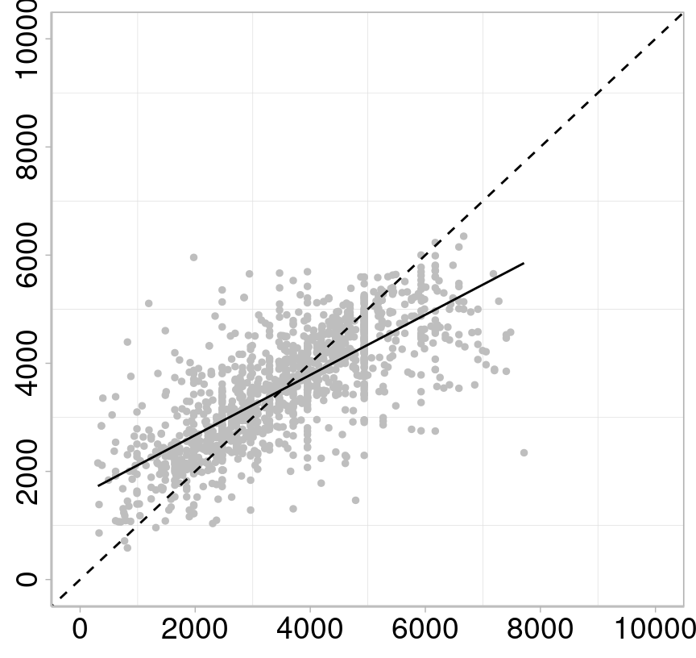

```r
print(pred.yield.test)
```

# Interpretable Machine Learning

## Create Model Explainer for Best_ML

```r
pred_fun_best_ML <- function(object, newdata)  {
  results <- as.vector(h2o.predict(object, as.h2o(newdata)))
  return(results)
}
```

### Explainer For Training Data

```r
explainer_train <- DALEX::explain(
  model = best_ML,
  type="regression",
  data = x_train,
  y = y_train,
  predict_function = pred_fun_best_ML,
  label = "The Best ML- Training"
)
```

## Permutation-based feature importance

```r
vip_train <- variable_importance(explainer_train, type="difference")
datatable(as.data.frame(vip_train),
          rownames = FALSE, options = list(pageLength = 10, scrollX = TRUE, round)) %>%
  formatRound(columns = -1, digits = 4)
```

```r
tiff( file="FIGURE_VIP.tif",
      width=6, height=18, units="in", res=600)
p.vip_train<-plot(vip_train)
print(p.vip_train)
dev.off()
```

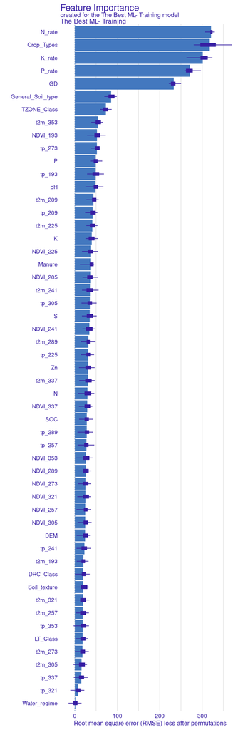

```r
print(p.vip_train)
```

### Create VIP table

```r
vip_train_stat<-vip_train %>%
  group_by(variable) %>%
  summarise(mean.loss = mean(dropout_loss, na.rm = TRUE),
            sd.loss = sd(dropout_loss, na.rm = TRUE),
            n.loss = n()) %>%
  mutate(se.loss = sd.loss / sqrt(n.loss),
         lower.ci.loss = mean.loss - qt(1 - (0.05 / 2), n.loss - 1) * se.loss,
         upper.ci.loss = mean.loss + qt(1 - (0.05 / 2), n.loss - 1) * se.loss)

vip_train_stat<-filter(vip_train_stat,  variable != "_baseline_")
vip_train_stat<-filter(vip_train_stat,  variable != "_full_model_")

vip_train_stat$Scale_VIP<-(vip_train_stat$mean.loss - min(vip_train_stat$mean.loss))/
                         (max(vip_train_stat$mean.loss)-min(vip_train_stat$mean.loss))

datatable(as.data.frame(vip_train_stat),
          rownames = FALSE, options = list(pageLength = 10, scrollX = TRUE, round)) %>%
  formatRound(columns = -1, digits = 4)
write.csv(vip_train_stat, "vip_stat_train.csv", row.names = F)
```

# Partial-dependence Profiles

```r
vip_stat_df<-vip_train_stat %>%
   arrange(desc(mean.loss))

var.names.stack=vip_stat_df[1]
var_1st=var.names.stack[1,]$variable
var_1st
```

```
## [1] "N_rate"
```

```r
var_2nd=var.names.stack[2,]$variable
var_2nd
```

```
## [1] "Crop_Types"
```

```r
var_3rd=var.names.stack[3,]$variable
var_3rd
```

```
## [1] "K_rate"
```

```r
var_4th=var.names.stack[4,]$variable
var_4th
```

```
## [1] "P_rate"
```

```r
var_5th=var.names.stack[5,]$variable
var_5th
```

```
## [1] "GD"
```

### PDP Plot of of 1st Important variable

```r
pdp_1st <- variable_effect(explainer_train,
                                      variable =  var_1st,
                                      type = "partial_dependency")
write.csv(pdp_1st , "PDP_1st.csv", row.names = F)
```

```r
tiff( file="FIGURE_PDP_1st.tif",
width=5, height=5, units="in", res=600)
pdp_1st.p<-plot(pdp_1st)
print(pdp_1st.p)
dev.off()
```

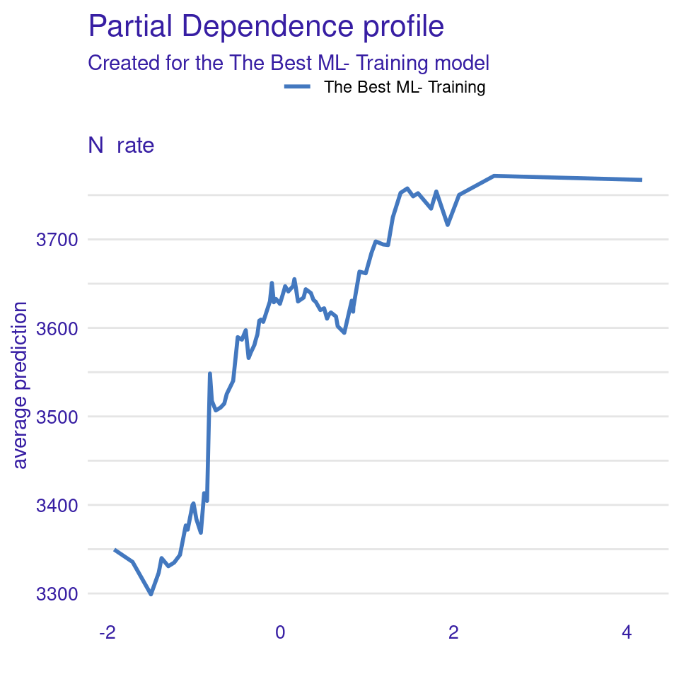

```r
print(pdp_1st.p)
```

### PDP Plot of of 2nd Important variable

```r
pdp_2nd <- variable_effect(explainer_train,
                                      variable =  var_2nd,
                                      type = "partial_dependency")
write.csv(pdp_2nd , "PDP_2nd.csv", row.names = F)
```

```r
tiff( file="FIGURE_PDP_2nd.tif",
width=5, height=5, units="in", res=600)
pdp_2nd.p<-plot(pdp_2nd)
print(pdp_2nd.p)
dev.off()
```

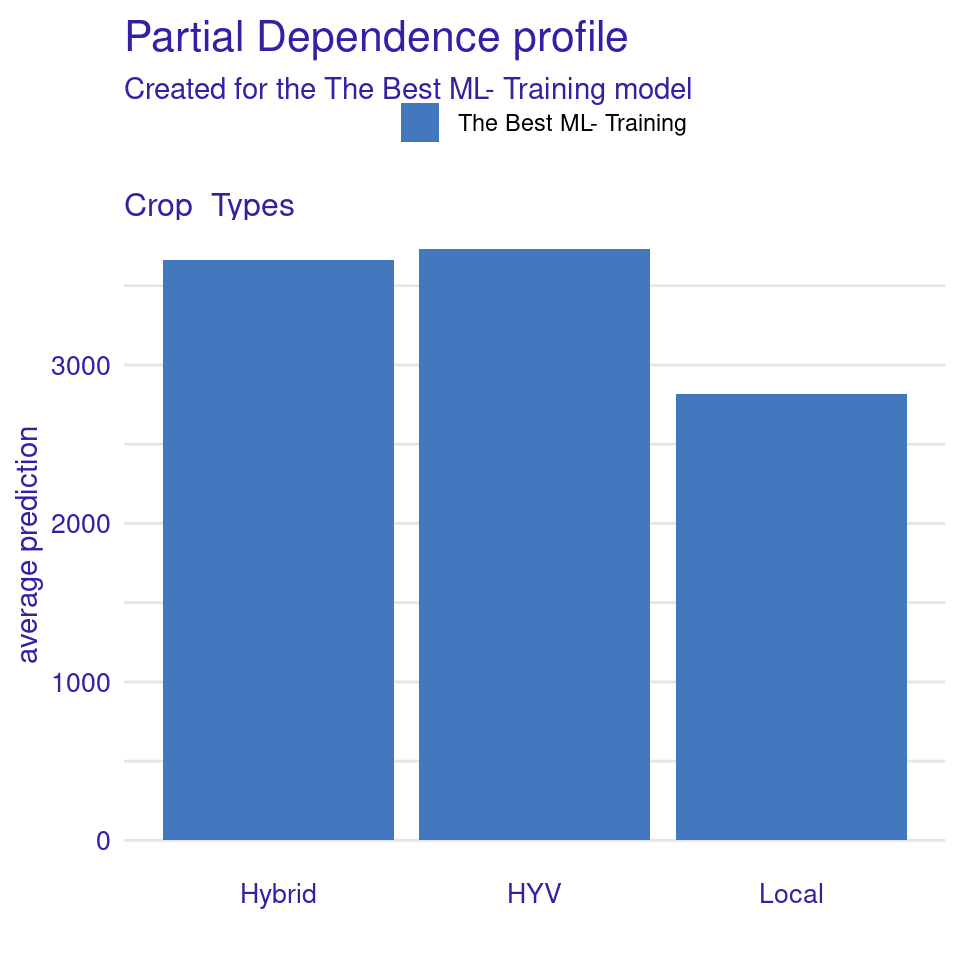

```r
print(pdp_2nd.p)
```

### PDP Plot of of 3rd Important variable

```r
pdp_3rd <- variable_effect(explainer_train,
                                      variable =  var_3rd,
                                      type = "partial_dependency")
write.csv(pdp_3rd , "PDP_3rd.csv", row.names = F)
```

```r
tiff( file="FIGURE_PDP_3rd_Aman.tif",
width=5, height=5, units="in", res=600)
pdp_3rd.p<-plot(pdp_3rd)
print(pdp_3rd.p)
dev.off()
```

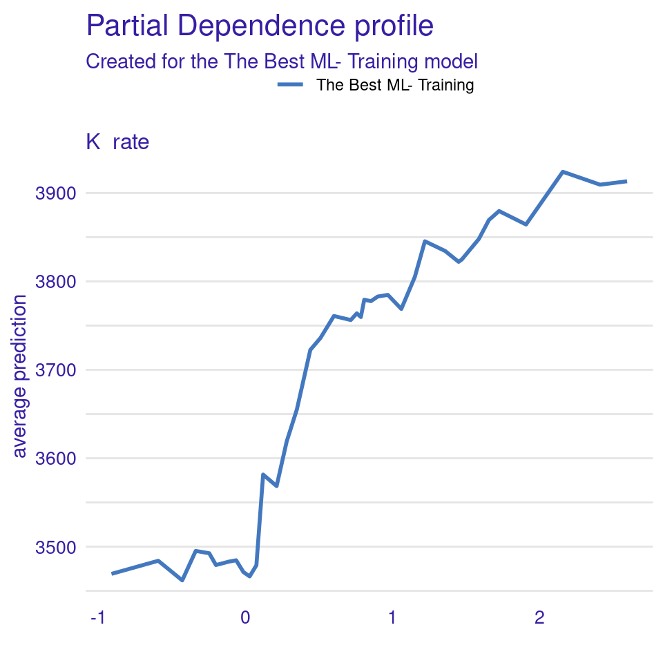

```r
print(pdp_3rd.p)
```

### PDP Plot of of 4th Important variable

```r
pdp_4th <- variable_effect(explainer_train,
                                      variable =  var_4th,
                                      type = "partial_dependency")
write.csv(pdp_4th , "PDP_4th.csv", row.names = F)
```

```r
tiff( file="FIGURE_PDP_4th.tif",
width=5, height=5, units="in", res=600)
pdp_4th.p<-plot(pdp_4th)
print(pdp_4th.p)
dev.off()
```

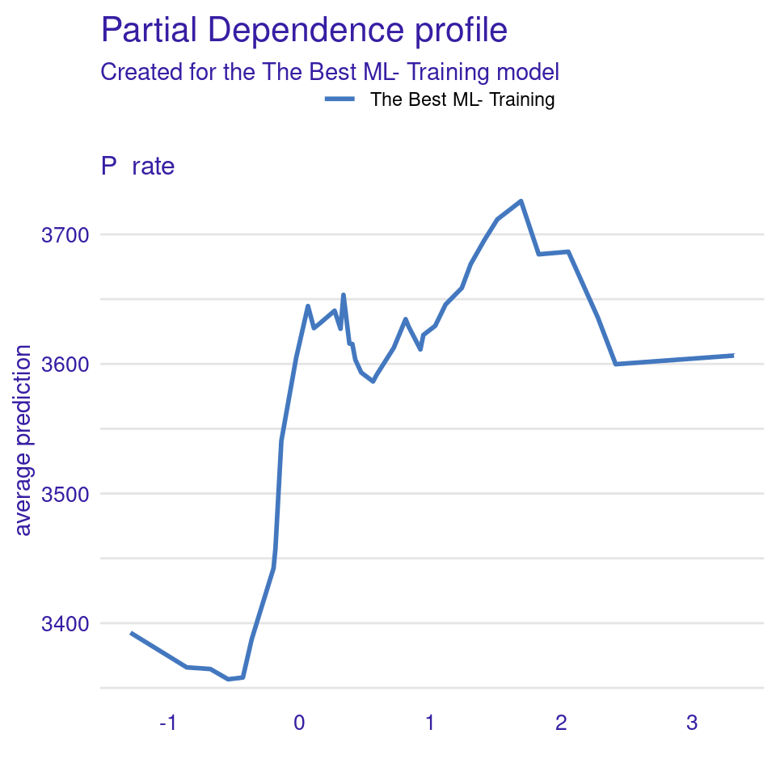

```r
print(pdp_4th.p)
```

### PDP Plot of of 5th Important variable

```r
pdp_5th <- variable_effect(explainer_train,
                                      variable =  var_5th,
                                      type = "partial_dependency")
write.csv(pdp_5th , "PDP_5th.csv", row.names = F)
```

```r
tiff( file="FIGURE_PDP_5th.tif",
width=5, height=5, units="in", res=600)
pdp_5th.p<-plot(pdp_5th)
print(pdp_5th.p)
dev.off()
```

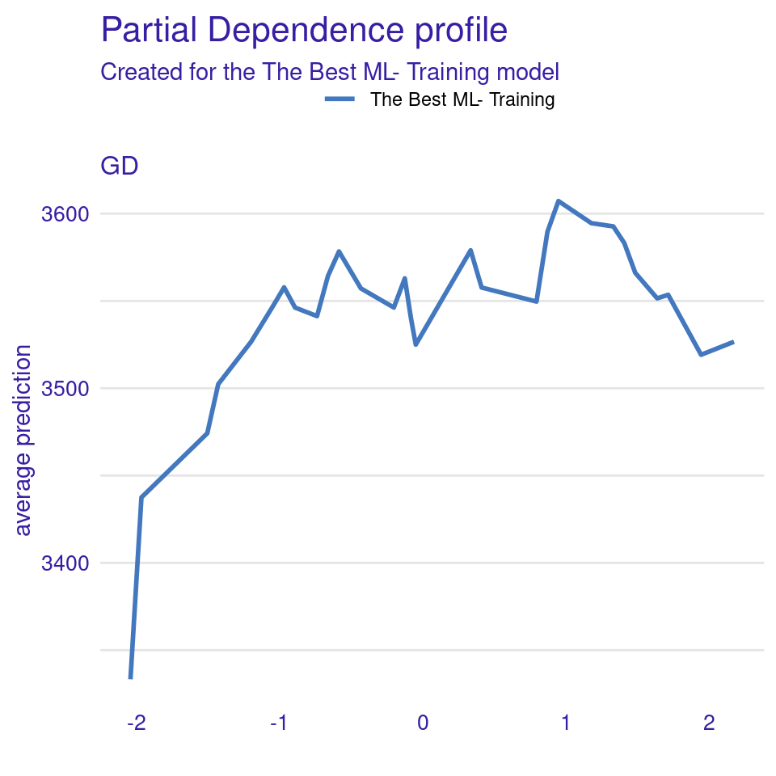

```r
print(pdp_5th.p)
```

## Partial, Accumulated and Local-dependence profils

```r
## !st important
pd_stack_1st <- model_profile(explainer = explainer_train, type = "partial", variables = var_1st)
ld_stack_1st <- model_profile(explainer = explainer_train, type = "conditional", variables = var_1st)
al_stack_1st <- model_profile(explainer = explainer_train, type = "accumulated", variables = var_1st)

write.csv(pd_stack_1st$agr_profiles, "partial_dependence_1st.csv")
write.csv(ld_stack_1st$agr_profiles, "local_dependence_1st.csv")
write.csv(al_stack_1st$agr_profiles, "accumulate_local_1st.csv")

# 2nd Important
pd_stack_2nd <- model_profile(explainer = explainer_train, type = "partial", variables = var_2nd)
ld_stack_2nd <- model_profile(explainer = explainer_train, type = "conditional", variables = var_2nd)
al_stack_2nd <- model_profile(explainer = explainer_train, type = "accumulated", variables = var_2nd)

write.csv(pd_stack_2nd$agr_profiles, "partial_dependence_2nd.csv")
write.csv(ld_stack_2nd$agr_profiles, "local_dependence_2nd.csv")
write.csv(al_stack_2nd$agr_profiles, "accumulated_local_2nd.csv")

# 3rd Important
pd_stack_3rd <- model_profile(explainer = explainer_train, type = "partial", variables = var_3rd)
ld_stack_3rd <- model_profile(explainer = explainer_train, type = "conditional", variables = var_3rd)
al_stack_3rd <- model_profile(explainer = explainer_train, type = "accumulated", variables = var_3rd)

write.csv(pd_stack_3rd$agr_profiles, "partial_dependence_3rd.csv")
write.csv(ld_stack_3rd$agr_profiles, "local_dependence_3rd.csv")
write.csv(al_stack_3rd$agr_profiles, "accumulated_local_3rd.csv")

# 4th Important
pd_stack_4th <- model_profile(explainer = explainer_train, type = "partial", variables = var_4th)
ld_stack_4th <- model_profile(explainer = explainer_train, type = "conditional", variables = var_4th)
al_stack_4th <- model_profile(explainer = explainer_train, type = "accumulated", variables = var_4th)

write.csv(pd_stack_4th$agr_profiles, "partial_dependence_4th.csv")
write.csv(ld_stack_4th$agr_profiles, "local_dependence_4th.csv")
write.csv(al_stack_4th$agr_profiles, "accumulated_local_4th.csv")

# 5th Important
pd_stack_5th <- model_profile(explainer = explainer_train, type = "partial", variables = var_5th)
ld_stack_5th <- model_profile(explainer = explainer_train, type = "conditional", variables = var_5th)
al_stack_5th <- model_profile(explainer = explainer_train, type = "accumulated", variables = var_5th)

write.csv(pd_stack_5th$agr_profiles, "partial_dependence_5th.csv")
write.csv(ld_stack_5th$agr_profiles, "local_dependence_5h.csv")
write.csv(al_stack_5th$agr_profiles, "accumulated_local_5th.csv")
```

## Feature interactions

```r
# create predictor object to pass to explainer functions
mod <- Predictor$new(best_ML, data =x_train)
inter<-Interaction$new(mod)
```

[output not shown]

[output not shown]

[output not shown]

[output not shown]

[output not shown]

[output not shown]

[output not shown]

[output not shown]

[output not shown]

[output not shown]

[output not shown]

[output not shown]

[output not shown]

[output not shown]

[output not shown]

[output not shown]

[output not shown]

```r
tiff( file="FIGURE_Interaction.tif",
width=6, height=18, units="in", res=600)
p.inter<-plot(inter)
print(p.inter)
dev.off()
```

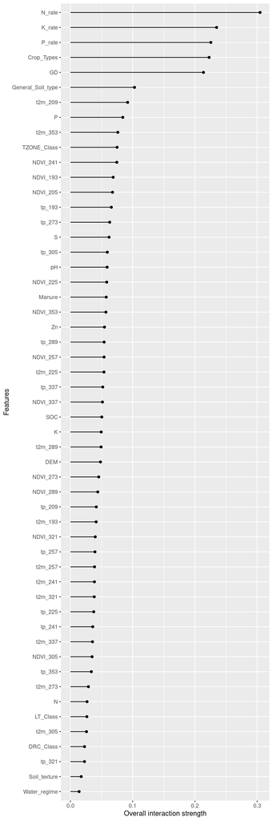

```r
print(p.inter)
```

```r
dat<-inter$results
write.csv(dat, "Feature_Interaction.csv", row.names=F)
```